# Text Analysis on Soil Microbiome

## Model Features

Next, we use GloVe and Principal Componenet Analysis to transform the taxa counts into the corresponding taxa-property transformation space. For the GloVe algorithm, we use the function “Dtm2Tcm”, which converts a document taxa matrix into a term co-occurence matrix. In this case, each bacterial “sample”, represents a document while each “taxa” represent a term. Bacterial counts per sample are equivalent to “terms” within a “document” in the natural language analysis framework.

```r
##GloVe Algorithm
#(slow) < 3 minutes, limited by RAM
cooccur_table <- textmineR::Dtm2Tcm(t(OTU_sub)) #converts a document term matrix into a term co-occurence matrix.
#define hyperparameters for glove model
glove = GlobalVectors$new(rank = 50, x_max = 10)
#fit main glove model word vectors
#using an intel i5 and GTX1060 3GB this step took approximately 10 minutes
wv_main = glove$fit_transform(cooccur_table, n_iter = 10, convergence_tol = 0.01, n_threads = 8)
```

```
## INFO  [08:41:44.644] epoch 1, loss 0.0626
## INFO  [08:43:20.145] epoch 2, loss 0.0467
## INFO  [08:45:05.046] epoch 3, loss 0.0365
## INFO  [08:46:43.533] epoch 4, loss 0.0333
## INFO  [08:48:17.559] epoch 5, loss 0.0323
## INFO  [08:49:49.598] epoch 6, loss 0.0317
## INFO  [08:51:23.191] epoch 7, loss 0.0314
## INFO  [08:51:23.193] Success: early stopping. Improvement at iterartion 7 is less then convergence_tol
```

```r
#pull out context word vectors
wv_context = glove$components
dim(wv_context)
```

```
## [1]    50 27472
```

```r
#combine main and context word vectors
word_vectors = wv_main + t(wv_context)
rf_word <- crossprod(x = word_vectors, y = OTU_sub) %>%
  t() %>%
  as.data.frame() %>%
  rownames_to_column() %>%
  rename(X.SampleID = rowname)
##PCR embeddings
pca_embeddings <- prcomp(t(OTU_sub),rank = 50)$rotation #50 principal components
rf_pca <- crossprod(x = pca_embeddings, y = OTU_sub) %>%
  t() %>%
  as.data.frame() %>%
  rownames_to_column()%>%
  rename(X.SampleID = rowname)
#relative abundance
rf_abundance <- apply(OTU_sub, MARGIN = 2, FUN = function(x){x/sum(x)}) %>%
  as.matrix() %>%
  t() %>%
  as.data.frame() %>%
  rownames_to_column("X.SampleID")

head(rf_word[1:10,1:10])
```

|  | X.SampleID | V1 | V2 | V3 | V4 | V5 | V6 | V7 | V8 | V9 |
| --- | --- | --- | --- | --- | --- | --- | --- | --- | --- | --- |
| 1 | 632.Agricultural.soil.wheat | 14435.61 | 79554.36 | -101750.685 | 206688.84 | -65084.80 | -254480.1 | 52285.82 | 149954.96 | 102255.19 |
| 2 | 659.NZFACE.R1.Browntop | -443510.54 | 16161.47 | -160986.127 | 241892.98 | -137383.26 | -877179.6 | -137946.33 | 558954.23 | 67211.71 |
| 3 | 659.NZFACE.R2.Ryegrass.24.4 | -106697.09 | 33528.14 | -63226.326 | 96219.52 | -79559.64 | -265768.5 | -58974.39 | 137506.58 | 38857.30 |
| 4 | 659.NZFACE.R5.Browntop | -96152.63 | 27895.29 | -56189.439 | 79783.67 | -57171.74 | -222036.4 | -52276.10 | 120198.43 | 30547.38 |
| 5 | 722.CL3.1.s.1.1.sequence | -18792.32 | 16201.01 | -55609.476 | 30911.67 | -19184.95 | -107851.4 | -28119.56 | -30387.03 | 48244.19 |
| 6 | 776.SN.BE.T3B | -41738.53 | 287116.93 | 4740.551 | 180899.73 | 294735.36 | -345966.1 | -11441.18 | 166979.23 | 45103.83 |

```r
#head(rf_pca[1:10,1:10])
#head(rf_abundance[1:10,1:10])
```

## Further Reshaping

After creating our taxa-property space, we add a column representing the metadata feature we are trying to predict to each dataframe. This is for ease of use of the Random Forest functionm which takes in a dataframe and predicts the values within a column of interest based on the other columns within the dataframe.

```r
soil_data <-  dplyr::filter(sample_data, grepl('soil', Description)) %>%
  rename(X.SampleID = "#SampleID") %>%
  filter(X.SampleID %in% rf_word$X.SampleID)


rf <- rf_word %>%
  left_join(soil_data, by = "X.SampleID") %>%
  mutate(response = envo_biome_2) %>%
  select( matches("V[0-9]{2}|response")) %>%
  mutate(response = gsub(" ", "_", response)) %>%
  mutate(response = gsub("_biome", "", response)) %>%
  mutate(response = as.factor(response))

#split into setaside, training, testing
split <-initial_split(rf, prop = 0.9)
setaside <- testing(split) #10% set aside
current <- initial_split(training(split), prop = 8/9)
training <- training(current) #80% training
testing <- testing(current) #10% testing
```

## Train Models

Before we run our models. We first subset each space into a training and test set.

```r
#fit random forest model
model <-  rand_forest(mode = "classification") %>%
  set_engine("randomForest") %>%
  fit(response ~ ., data = training)

#predict on training set
m_train <- predict(model, training) %>% bind_cols(training)
#predict on testing set
m_test <- predict(model,testing) %>% bind_cols(testing)

#probability predictions
mp_test <- predict(model, testing, type = "prob") %>%
  bind_cols(m_test) %>%
  select(-matches("V.*")) %>%
  rename(estimate = .pred_class)

mp_train <- predict(model, training, type = "prob") %>%
  bind_cols(m_train) %>%
  select(-matches("V.*")) %>%
  rename(estimate = .pred_class)
##
```

## accuracy

```r
multi_metric <- metric_set(ppv, npv, sens, spec, precision, recall, accuracy,kap, pr_auc, roc_auc)
stats_train <- multi_metric(mp_train, truth = response, estimate = estimate,... = matches(".pred.*"));stats_train
```

| .metric | .estimator | .estimate |
| --- | --- | --- |
| ppv | macro | 1 |
| npv | macro | 1 |
| sens | macro | 1 |
| spec | macro | 1 |
| precision | macro | 1 |
| recall | macro | 1 |
| accuracy | multiclass | 1 |
| kap | multiclass | 1 |
| pr_auc | macro | 1 |
| roc_auc | hand_till | 1 |

```r
write_csv(stats_train, paste(outputFolder, title, "_stats_train.csv", sep = ""))
stats_test <- multi_metric(mp_test, truth = response, estimate = estimate, ... = matches(".pred.*")); stats_test
```

| .metric | .estimator | .estimate |
| --- | --- | --- |
| ppv | macro | NA |
| npv | macro | NA |
| sens | macro | 0.8000000 |
| spec | macro | 0.9666667 |
| precision | macro | 0.8750000 |
| recall | macro | 0.8000000 |
| accuracy | multiclass | 0.8333333 |
| kap | multiclass | 0.7857143 |
| pr_auc | macro | NA |
| roc_auc | hand_till | NA |

```r
write_csv(stats_test, paste(outputFolder, title, "_stats_test.csv", sep = ""))


custom_evaluate <- function(x){
  res <- list()
  temp <- x %>%
    as.data.frame() %>%
    mutate(Freq = as.numeric(Freq))
  colnames(temp) <- c("predict", "observed", "Freq")
  temp <- temp %>%
    mutate(predict = as.character(predict), observed = as.character(observed))
  categories <- unique(temp$predict)
  for(i in 1:length(categories)){
    subject = categories[i]
    TP <- filter(temp, observed == subject & predict == subject) %>%
      summarize(n = sum(Freq))
    FP <- filter(temp, observed != subject & predict == subject) %>%
      summarize(n = sum(Freq))
    TN <- filter(temp, observed != subject & predict != subject) %>%
      summarize(n = sum(Freq))
    FN <- filter(temp, observed == subject & predict != subject) %>%
      summarize(n = sum(Freq))
    PPV <- TP/(TP+FP)
    NPV <- TN/(FN+TN)
    sensitivity <- TP/(TP+FN)
    specificity <- TN/(FP+TN)
    temp_res <- as.numeric(c(TP, FP, TN, FN, PPV, NPV, sensitivity, specificity))
    names(temp_res) <- c("TP", "FP", "TN", "FN", "PPV", "NPV", "sensitivity", "specificity")
    res[[i]] <- temp_res
  }
  res <- data.frame(do.call(rbind, res))
  res <- rbind(res, (apply(res, 2, mean, na.rm = T)))
  rownames(res) <- c(categories, "average")
  return(res)
}
custom_stats_train <- custom_evaluate(conf_mat(mp_train, response, estimate)$table); custom_stats_train
```

|  | TP | FP | TN | FN | PPV | NPV | sensitivity | specificity |
| --- | --- | --- | --- | --- | --- | --- | --- | --- |
| anthropogenic_terrestrial | 22.000000 | 0 | 31.00000 | 0 | 1 | 1 | 1 | 1 |
| desert | 6.000000 | 0 | 47.00000 | 0 | 1 | 1 | 1 | 1 |
| forest | 8.000000 | 0 | 45.00000 | 0 | 1 | 1 | 1 | 1 |
| grassland | 5.000000 | 0 | 48.00000 | 0 | 1 | 1 | 1 | 1 |
| shrubland | 5.000000 | 0 | 48.00000 | 0 | 1 | 1 | 1 | 1 |
| tundra | 7.000000 | 0 | 46.00000 | 0 | 1 | 1 | 1 | 1 |
| average | 8.833333 | 0 | 44.16667 | 0 | 1 | 1 | 1 | 1 |

```r
write_csv(custom_stats_train, paste(outputFolder, title, "_customstats_train.csv", sep = ""))
custom_stats_test <- custom_evaluate(conf_mat(mp_test, response, estimate)$table); custom_stats_test
```

|  | TP | FP | TN | FN | PPV | NPV | sensitivity | specificity |
| --- | --- | --- | --- | --- | --- | --- | --- | --- |
| anthropogenic_terrestrial | 1.0000000 | 1.0000000 | 4.000000 | 0.0000000 | 0.500 | 1.0000000 | 1.0 | 0.8000000 |
| desert | 0.0000000 | 0.0000000 | 5.000000 | 1.0000000 | NaN | 0.8333333 | 0.0 | 1.0000000 |
| forest | 0.0000000 | 0.0000000 | 6.000000 | 0.0000000 | NaN | 1.0000000 | NaN | 1.0000000 |
| grassland | 1.0000000 | 0.0000000 | 5.000000 | 0.0000000 | 1.000 | 1.0000000 | 1.0 | 1.0000000 |
| shrubland | 2.0000000 | 0.0000000 | 4.000000 | 0.0000000 | 1.000 | 1.0000000 | 1.0 | 1.0000000 |
| tundra | 1.0000000 | 0.0000000 | 5.000000 | 0.0000000 | 1.000 | 1.0000000 | 1.0 | 1.0000000 |
| average | 0.8333333 | 0.1666667 | 4.833333 | 0.1666667 | 0.875 | 0.9722222 | 0.8 | 0.9666667 |

```r
write_csv(custom_stats_test, paste(outputFolder, title, "_customstats_test.csv", sep = ""))
```

## ROC Graph

an ROC Graph is a graphical plot that illustrates the diagnostic ability of a binary classifier system as its discrimination threshold is varied. The ROC curve is created by plotting the true positive rate (TPR) against the false positive rate (FPR) at various threshold settings.

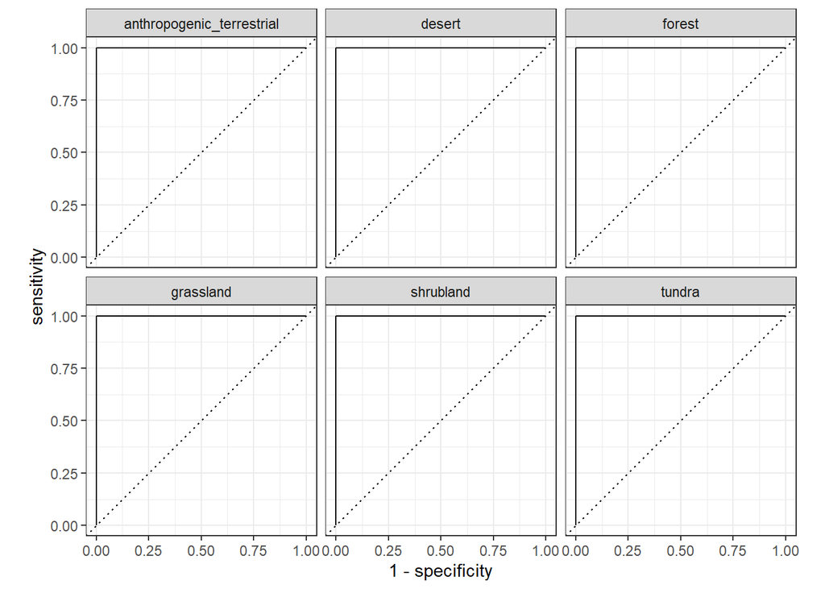

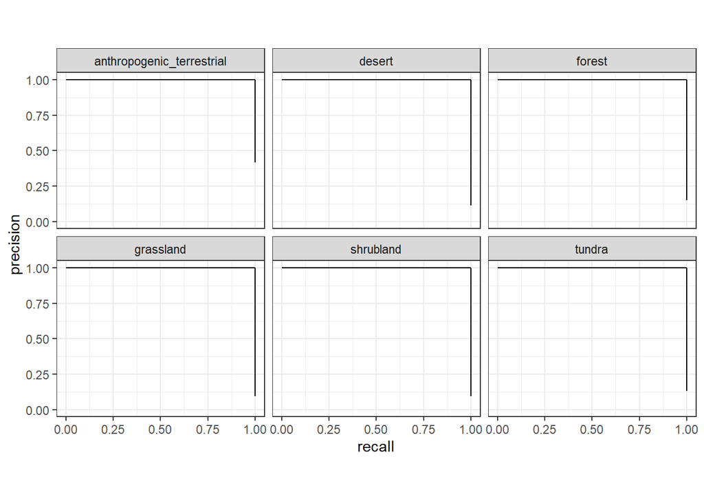

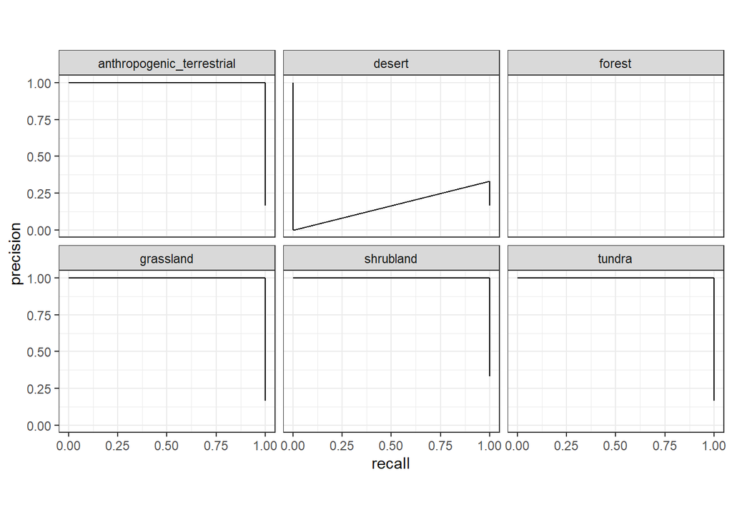

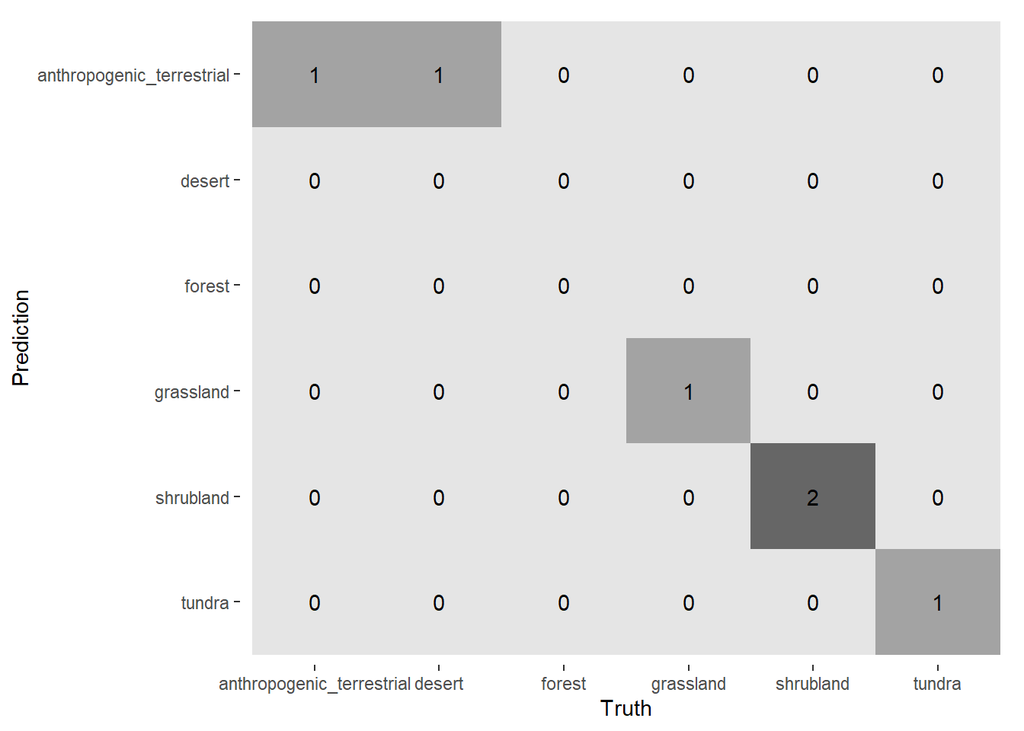

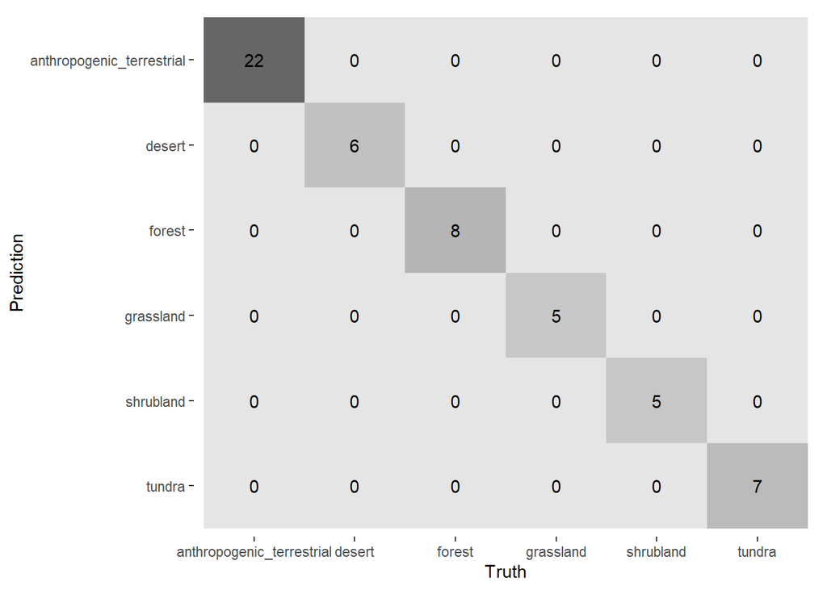